# Cell type matching across non-overlapping neuroanatomical regions - M1 and MTG

Yun (Renee) Zhang, zhangy@jcvi.org

August 24, 2021

Download data [here](https://jcvioffice365-my.sharepoint.com/personal/zhangy_jcvi_org/_layouts/15/onedrive.aspx?id=%2Fpersonal%2Fzhangy%5Fjcvi%5Forg%2FDocuments%2FFR%2DMatch%20demo%20data%2FTutorial%5FM1%5FMTG). For how to construct the data objects, see [Tutorial](https://jcventerinstitute.github.io/celligrate/FRmatch-vignette.html).

Quick facts about the datasets:

- M1
  - Anatomic region: healthy human primary motor cortex (M1)
  - Experimental platform: SMART-seq v4 (SSv4)
  - Sample type: single-nucleus
  - Citation: [Evolution of cellular diversity in primary motor cortex of human, marmoset monkey, and mouse](https://www.biorxiv.org/content/10.1101/2020.03.31.016972v2). More specifically, the M1 data used here is the human SSv4 subset of the cross-species M1 data published in the above publication (see Figure 1b).
- MTG
  - Anatomic region: healthy human middle temporal gyrus (MTG)
  - Experimental platform: SMART-seq v4
  - Sample type: single-nucleus
  - Citation: [Conserved cell types with divergent features in human versus mouse cortex](https://www.nature.com/articles/s41586-019-1506-7)

Load library and data.

```r
library(FRmatch)
load("sce-M1.rda")
load("sce-MTG.rda")
```

Take a look at the gene expression data distribution. *For the SSv4 data, we followed the standard preprocessing of SMART-seq data by taking the logCPM of the raw count data, which was stored in the `@assays$logcounts` slot of the data object.* Since both datasets are generated using the same experimental platform and follow similar distribution, no normalization is needed.

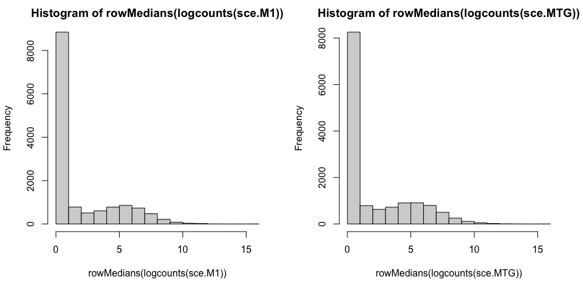

```r
par(mfrow=c(1,2))
hist(rowMedians(logcounts(sce.M1)))
hist(rowMedians(logcounts(sce.MTG)))
```

Take an overview of the cell type clusters in both datasets. *Only cells with cluster labels are used, i.e. removed cells without label from the original publication.*

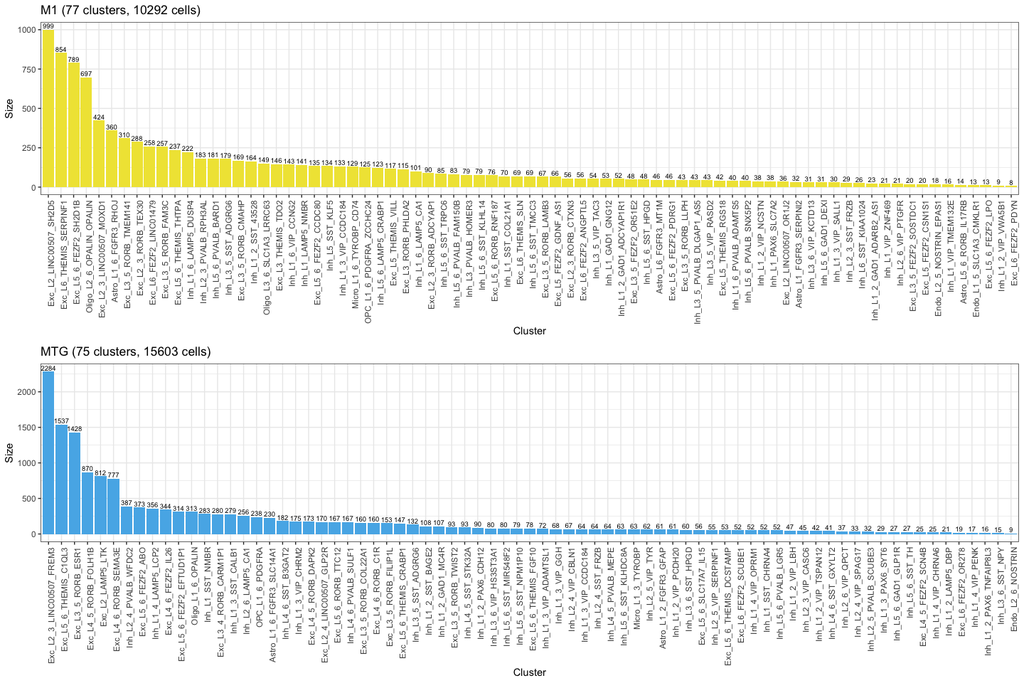

```r
## plot cluster size
plot_clusterSize(sce.M1, sce.MTG, name.E1 = "M1", name.E2 = "MTG")
```

The following codes are suggested to plot all cell type barcode plots in an assigned folder. NOT RUN HERE.

```r
## barcode plots
clusters.M1 <- unique(colData(sce.M1)$cluster_membership)
clusters.MTG <- unique(colData(sce.ref75)$cluster_membership)

## by M1 markers
common.markers.M1 <- intersect(unique(sce.M1@metadata$cluster_marker_info$markerGene), rownames(sce.ref75))
for (cl in clusters.MTG){
  plot_cluster_by_markers(sce.M1, sce.ref75, cluster.name = cl,
                          name.E2 = "MTG.",
                          filename = paste0("plot_barcode_M1_markers/MTG_",cl,".pdf"))
}
for (cl in clusters.M1){
  plot_cluster_by_markers(sce.M1[common.markers.M1,], cluster.name = cl,
                          name.E1 = "M1.",
                          filename = paste0("plot_barcode_M1_markers/M1_",cl,".pdf"))
}

## by MTG markers
common.markers.MTG <- intersect(unique(sce.ref75@metadata$cluster_marker_info$markerGene), rownames(sce.M1))
for (cl in clusters.M1){
  plot_cluster_by_markers(sce.ref75, sce.M1, cluster.name = cl,
                          name.E2 = "M1.",
                          filename = paste0("plot_barcode_MTG_markers/M1_",cl,".pdf"))
}
for (cl in clusters.MTG){
  plot_cluster_by_markers(sce.ref75[common.markers.MTG,], cluster.name = cl,
                          name.E1 = "MTG.",
                          filename = paste0("plot_barcode_MTG_markers/MTG_",cl,".pdf"))
}
```

# Run FR-Match

One direction.

```r
##--------------------------##
## M1 (query) --> MTG (ref) ##
##--------------------------##
rst.M1toMTG <- FRmatch(sce.query=sce.M1, sce.ref=sce.MTG, prefix=c("M1.","MTG."),
                       filter.size=5, subsamp.size=20) #filter.size=5 is a placeholder, all clusters are used
```

The other direction.

```r
##--------------------------##
## MTG (query) --> M1 (ref) ##
##--------------------------##
rst.MTGtoM1 <- FRmatch(sce.query=sce.MTG, sce.ref=sce.M1, prefix=c("MTG.","M1."),
                       filter.size=5, subsamp.size=20) #filter.size=5 is a placeholder, all clusters are used
```

Combined plot of the bi-directional FR-Match results, showing two-way matches only.

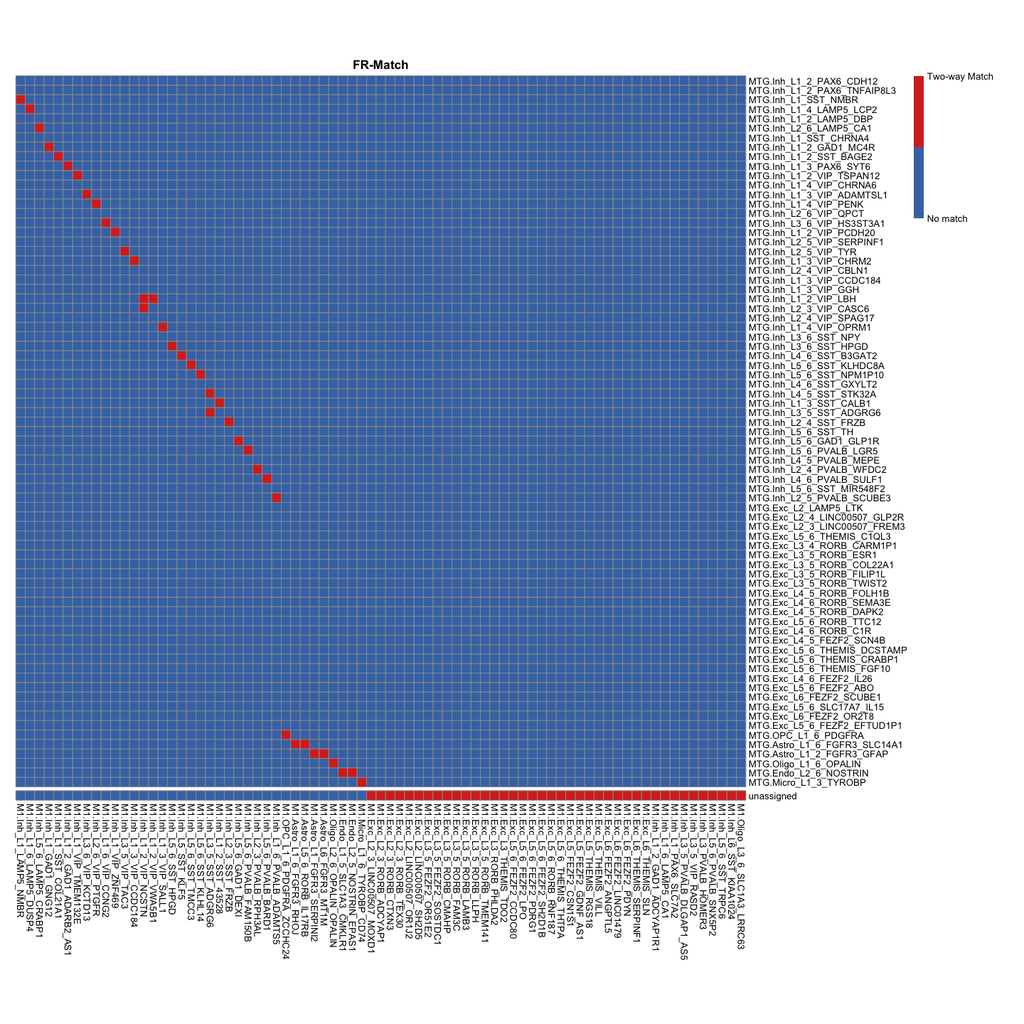

```r
plot_bi_FRmatch(rst.M1toMTG, rst.MTGtoM1, name.E1="M1.", name.E2="MTG.", two.way.only=TRUE)
```

# Some one-directional results

## M1 (query) to MTG (reference)

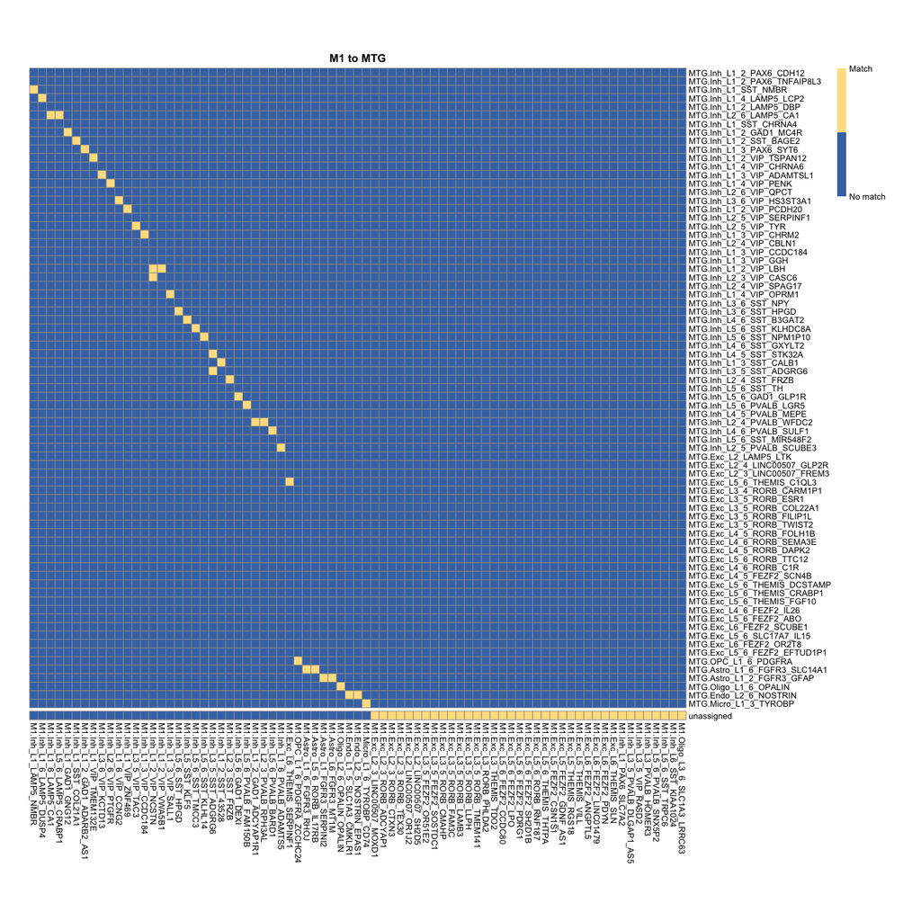

```r
plot_FRmatch(rst.M1toMTG, main="M1 to MTG")
```

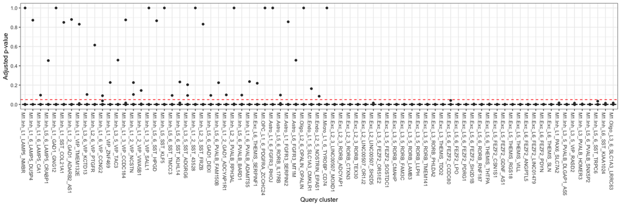

```r
plot_FRmatch(rst.M1toMTG, type="padj")
```

```r
## top match
predict_most_similar_cluster(rst.M1toMTG)
```

| query_cluster | most_similar_ref_cluster | padj |
| --- | --- | --- |
| M1.Astro_L1_6_FGFR3_RHOJ | MTG.Astro_L1_6_FGFR3_SLC14A1 | 1.000000e+00 |
| M1.Inh_L1_2_SST_43528 | MTG.Inh_L1_3_SST_CALB1 | 1.000000e+00 |
| M1.Inh_L1_3_VIP_SALL1 | MTG.Inh_L1_4_VIP_OPRM1 | 1.000000e+00 |
| M1.Inh_L1_GAD1_GNG12 | MTG.Inh_L1_2_GAD1_MC4R | 1.000000e+00 |
| M1.Inh_L1_LAMP5_NMBR | MTG.Inh_L1_SST_NMBR | 1.000000e+00 |
| M1.Inh_L2_3_PVALB_RPH3AL | MTG.Inh_L2_4_PVALB_WFDC2 | 1.000000e+00 |
| M1.Inh_L5_SST_KLF5 | MTG.Inh_L4_6_SST_B3GAT2 | 1.000000e+00 |
| M1.Micro_L1_6_TYROBP_CD74 | MTG.Micro_L1_3_TYROBP | 1.000000e+00 |
| M1.Oligo_L2_6_OPALIN_OPALIN | MTG.Oligo_L1_6_OPALIN | 1.000000e+00 |
| M1.OPC_L1_6_PDGFRA_ZCCHC24 | MTG.OPC_L1_6_PDGFRA | 1.000000e+00 |

[output cut: 67 more lines]

## MTG (query) to M1 (reference)

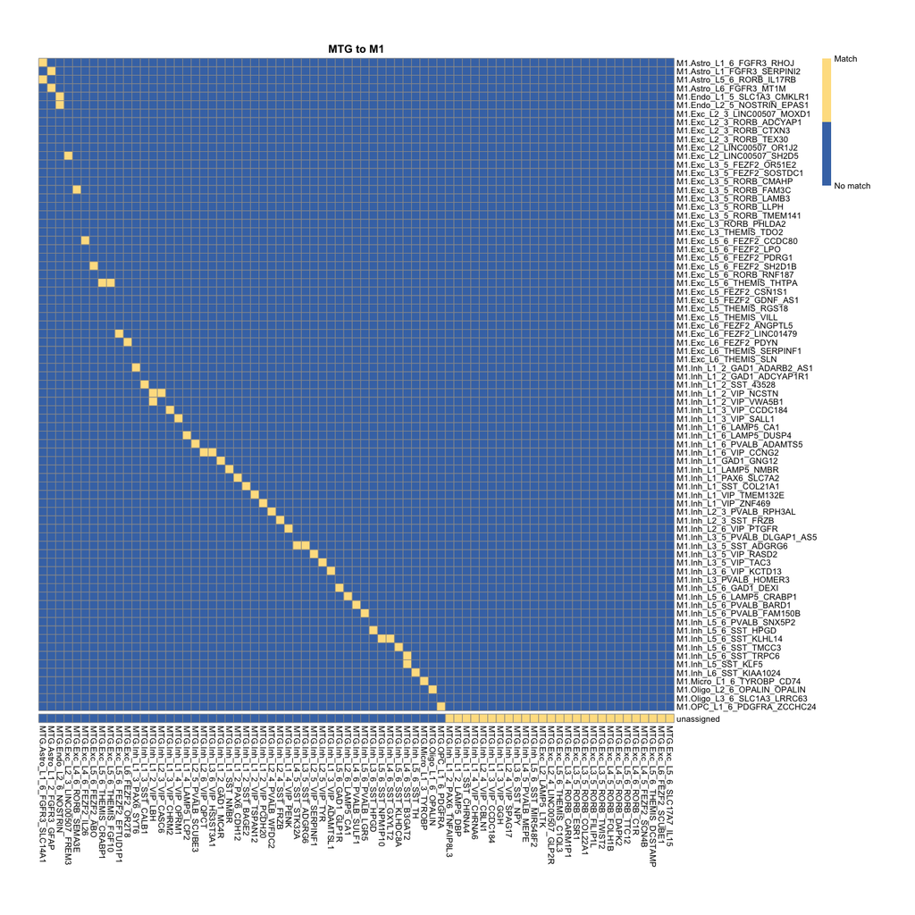

```r
plot_FRmatch(rst.MTGtoM1, main="MTG to M1")
```

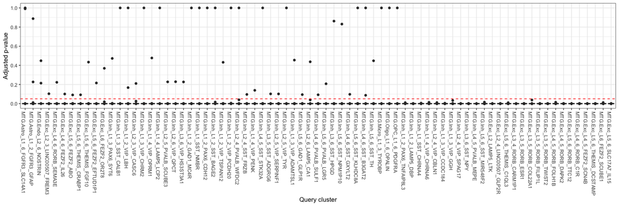

```r
plot_FRmatch(rst.MTGtoM1, type="padj")
```

```r
## top match
predict_most_similar_cluster(rst.MTGtoM1)
```

| query_cluster | most_similar_ref_cluster | padj |
| --- | --- | --- |
| MTG.Inh_L1_2_PAX6_CDH12 | M1.Inh_L1_PAX6_SLC7A2 | 1.0000000000 |
| MTG.Inh_L1_SST_NMBR | M1.Inh_L1_LAMP5_NMBR | 1.0000000000 |
| MTG.Inh_L1_4_LAMP5_LCP2 | M1.Inh_L1_6_LAMP5_DUSP4 | 1.0000000000 |
| MTG.Inh_L1_2_GAD1_MC4R | M1.Inh_L1_GAD1_GNG12 | 1.0000000000 |
| MTG.Inh_L1_2_SST_BAGE2 | M1.Inh_L1_SST_COL21A1 | 1.0000000000 |
| MTG.Inh_L1_2_VIP_PCDH20 | M1.Inh_L1_VIP_ZNF469 | 1.0000000000 |
| MTG.Inh_L2_5_VIP_TYR | M1.Inh_L3_5_VIP_TAC3 | 1.0000000000 |
| MTG.Inh_L1_3_VIP_CHRM2 | M1.Inh_L1_3_VIP_CCDC184 | 1.0000000000 |
| MTG.Inh_L1_2_VIP_LBH | M1.Inh_L1_2_VIP_NCSTN | 1.0000000000 |
| MTG.Inh_L4_6_SST_B3GAT2 | M1.Inh_L5_SST_KLF5 | 1.0000000000 |

[output cut: 65 more lines]

## The full bi-directional plot

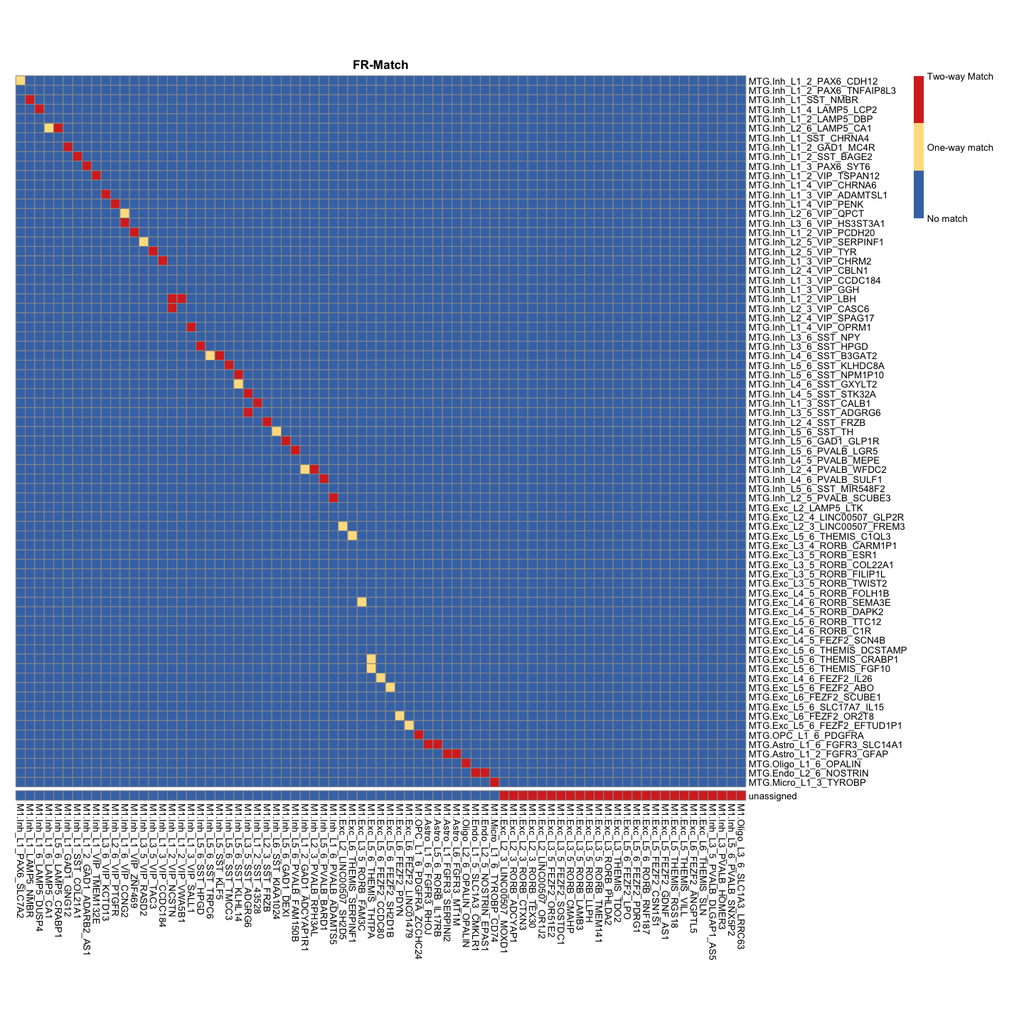

```r
plot_bi_FRmatch(rst.M1toMTG, rst.MTGtoM1, name.E1="M1.", name.E2="MTG.")
```